# Explaining Song Popularity

### Collinearity

As a next step, we check for collinearity issues. We will use the transformed model and calculate the vif. We define vif values higher than 5 as problematic.

```r
formula = "popularity~danceability+energy+exp(loudness)+speechiness+acousticness+instrumentalness+liveness+valence+tempo+exp(duration_m)+key+mode+time_signature+genre"
model_add_quant_vif = lm(formula, data = quantile_data_trn)
```

```r
vif_values = faraway::vif(model_add_quant_vif)
(problematic_variables = names(vif_values[vif_values > 5]))
```

```
## [1] "time_signature1" "time_signature3" "time_signature4" "time_signature5"
```

We see that the factor variable time_signature has vif values above the threshold of 5. This is problematic, it indicates that those variables are contributing to multicollinearity in our regression model. Therefore we remove them and do the test again.

```r
formula = "popularity~danceability+energy+exp(loudness)+speechiness+acousticness+instrumentalness+liveness+valence+tempo+exp(duration_m)+key+mode+genre"
model_add_quant_no_vif = lm(formula, data = quantile_data_trn)
```

```r
vif_values = faraway::vif(model_add_quant_no_vif)
(problematic_variables = names(vif_values[vif_values > 5]))
```

```
## character(0)
```

```r
model_add_quant_no_vif_check = check_model(model_add_quant_no_vif, quantile_data_tst)
rownames(model_add_quant_no_vif_check) = c("Additive Qunatile Normalized No VIF")
model_add_quant_no_vif_check
```

```
##                                     adjusted_r_squared rsme_test mae_test
## Additive Qunatile Normalized No VIF             0.3846     3.755    2.985
##                                     loocv_rmse   shapiro bptest
## Additive Qunatile Normalized No VIF      3.764 7.462e-13      0
```

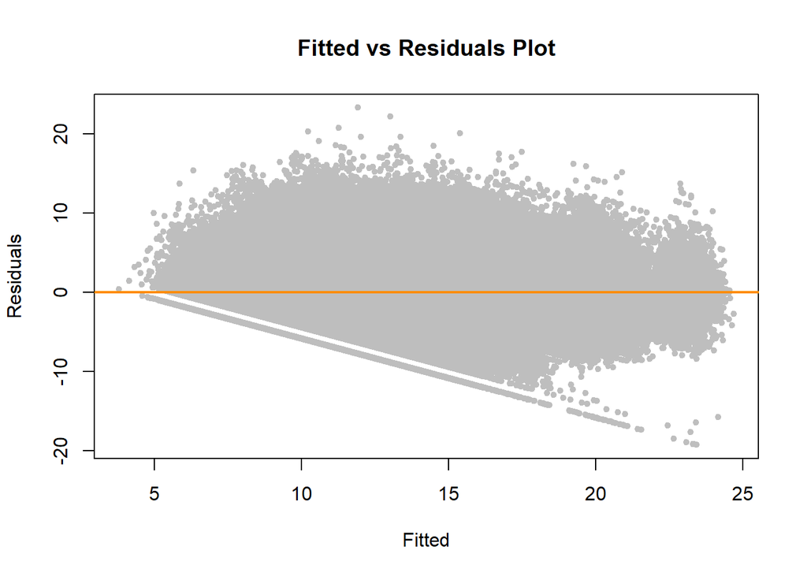

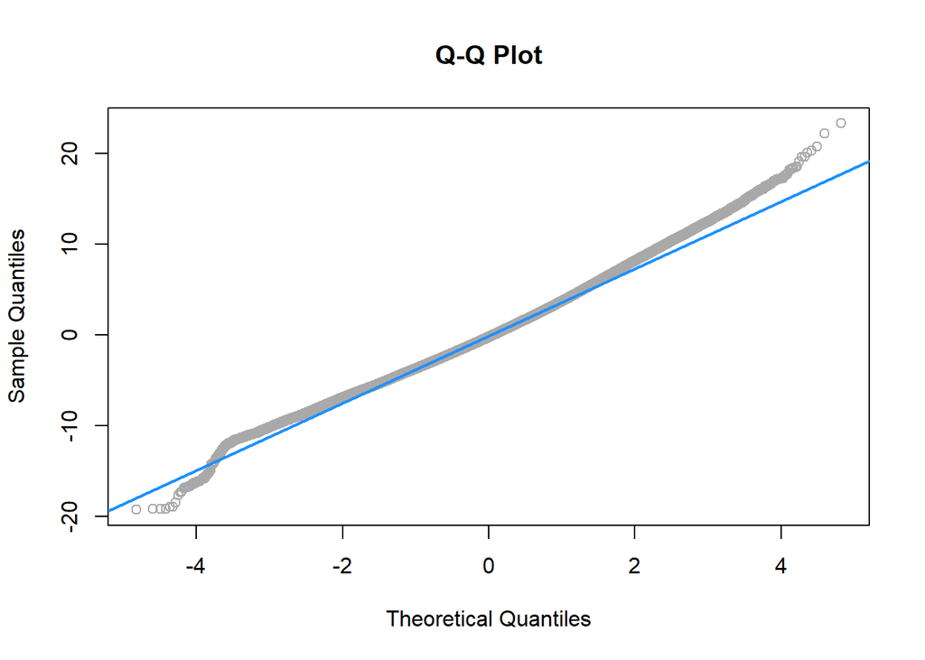

```r
plot_model(model_add_quant_no_vif)
```

Now all predictors are below the threshold. No further changes are required towards the constant variance and normality assumptions. The means we got a simpler and better explainable model with likely the same quality in terms of prediction.

### Interaction

In the data analysis we stated that interactions might be helpful to better explain the popularity. In this step we will evaluate that. Some interactions were added to the previous model, to see if we can get a better model.

```r
formula = "popularity~danceability+energy+exp(loudness)+speechiness+acousticness+instrumentalness+liveness+valence+tempo+exp(duration_m)+key+mode+time_signature+genre+danceability:genre+speechiness:liveness+valence:tempo+energy:tempo+acousticness:instrumentalness+danceability:liveness"
model_int_quant_trans = lm(formula, data = quantile_data_trn)
```

```r
model_int_quant_trans_check = check_model(model_int_quant_trans, quantile_data_tst)
rownames(model_int_quant_trans_check) = c("Interaction Qunatile Normalized")
model_int_quant_trans_check
```

```
##                                 adjusted_r_squared rsme_test mae_test
## Interaction Qunatile Normalized             0.3967     3.718    2.953
##                                 loocv_rmse  shapiro bptest
## Interaction Qunatile Normalized      3.727 5.34e-12      0
```

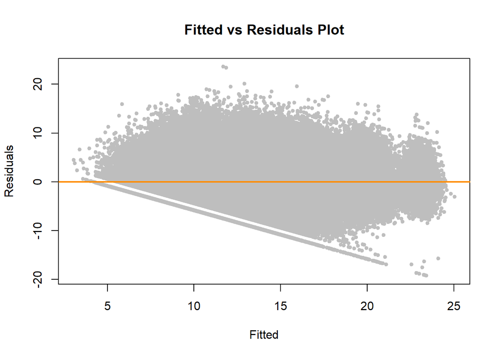

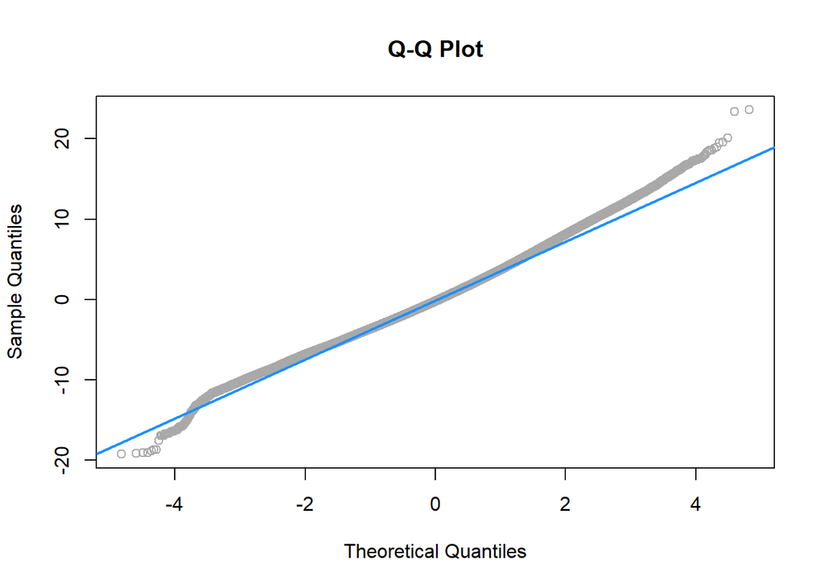

```r
plot_model(model_int_quant_trans)
```

The model performs slightly better in terms of meeting the normal assumption. The other test values do not vary. Therefore we get a slightly better model for the cost of explainability.

### Explainability

Our goal is to achieve a simpler healthy model that will help us in explaining the popularity better while getting decent RMSE and MAE on the test set. Previously we suspected that the genre is produced by an algorithm that is assessing a song using some features we see here, so we will not use any genre predictor as it might be confusing. Also, we saw that the key, mode and time signature are not changing the average popularity so much so we will try to drop them as well. Finally, we will handpick a few predictors that were the most promising and not correlated between them, and interact them with the year to create coefficients for each year.

```r
model_explain = lm(popularity ~ year * (danceability + acousticness + instrumentalness + speechiness + liveness + duration_m),
                   data = quantile_data_trn)
```

```r
model_explain_check = check_model(model_explain, quantile_data_tst)
rownames(model_explain_check) = c("Explainable By Year")
model_explain_check
```

```
##                     adjusted_r_squared rsme_test mae_test loocv_rmse   shapiro
## Explainable By Year             0.1703      4.36     3.48      4.371 2.886e-09
##                     bptest
## Explainable By Year      0
```

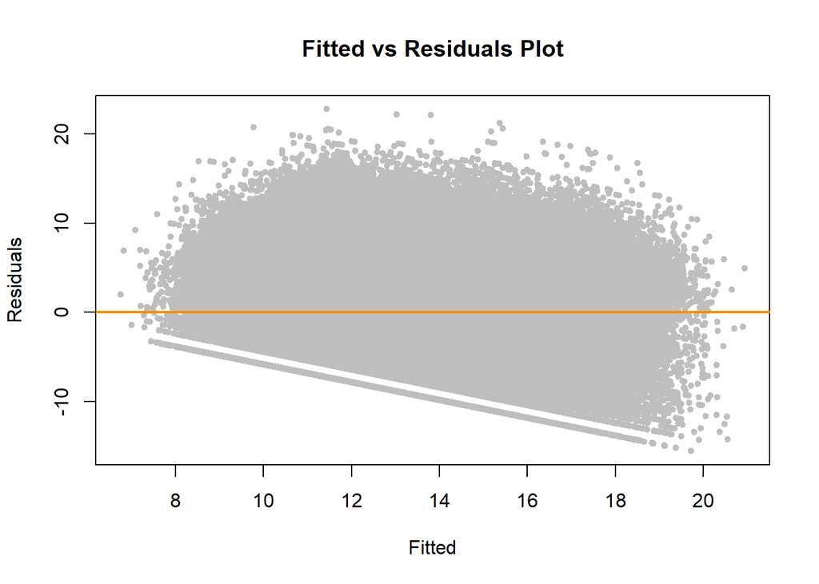

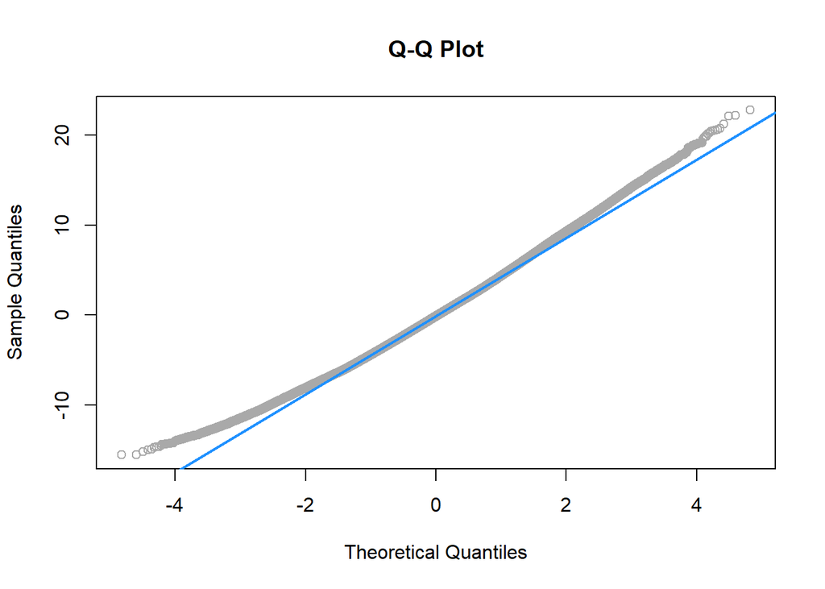

```r
plot_model(model_explain)
```